# Part II - USA Trips

## by Adébayo Gael

## Investigation Overview

> In this research, I wanted to analyze airline travel data

## Dataset Overview

> Our dataset contains data on 7.4 million trips between airports in the United States in the year 2007. It contains variables such as flight duration, distance and delays

## Proportion of the air fleet in 2007

> The air fleet in 2007 is dominated by the WN company. She manages 3 trips out of 20 all over the United States. It's almost as much as the other two most popular companies, namely: AA and OO

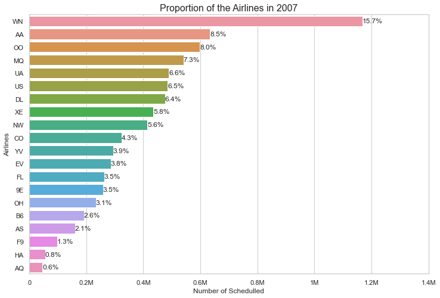

## Mean Distance by Airline

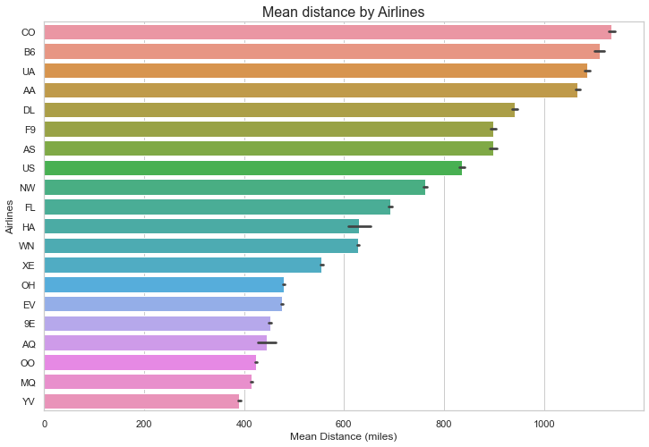

## Mean Delay time by Airlines

> The American companies in our study in part 1 proved to be very retarding. The most famous in this sense is EV. Surely the reason why this company is little used (only 3%). It should be noted that the least solicited companies, surely new AQ and HA, are facing no major delays.

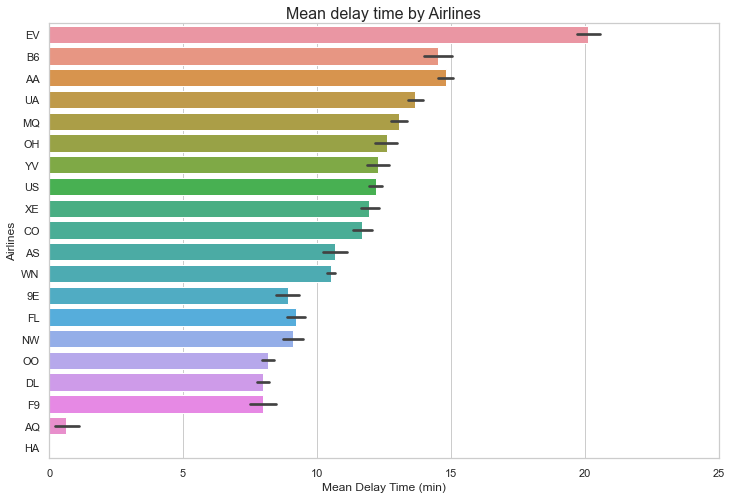

## Mean Deptime by Airlines

> All companies generally take off during the day. however they are all able to take off at all hours depending on schedules and delays.

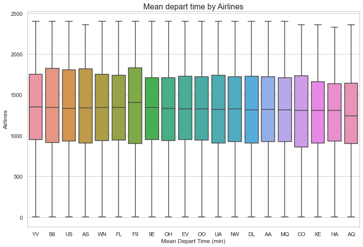

## Conclusion

> We can conclude that the air fleet is dominated by WN. It is responsible for 15% of flights on American territory. It specializes in medium-distance trips, with an average distance of 600 miles on all the trips it was able to make during the period. Like almost all other companies, it is subject to delays. Note also that our study allowed us to find a company to encourage, HA. For a start in air transport, it is not yet affected by delay concerns.